# Yelp database exploratory analysis

Behind this short python module lies another attempt at practising on some data manipulation skills, from playing with json files, organizing and 'cleaning' a dataframe with Pandas, but also performing some analysis and visualize it through matplotlib/seaborn or thanks to Folium. At this point, such work could be the start of a larger project aiming at analyzing Yelp database more in-depth, and we could keep on studying businesses and their ratings, as well as integrate other data from Yelp.

```python
import numpy as np
import pandas as pd
import matplotlib.pyplot as plt
%matplotlib inline
import seaborn as sns
import folium
```

```python
# Reading all the yelp dataset json files
checkin_json_path = 'yelp_academic_dataset_checkin.json'
checkin = pd.read_json(checkin_json_path, lines=True)
```

```python
checkin.info()
```

```
<class 'pandas.core.frame.DataFrame'>
RangeIndex: 175187 entries, 0 to 175186
Data columns (total 2 columns):
 #   Column       Non-Null Count   Dtype
---  ------       --------------   -----
 0   business_id  175187 non-null  object
 1   date         175187 non-null  object
dtypes: object(2)
memory usage: 2.7+ MB
```

```python
business_json_path = 'yelp_academic_dataset_business.json'
business = pd.read_json(business_json_path, lines=True)
```

```python
business.info()
```

```
<class 'pandas.core.frame.DataFrame'>
RangeIndex: 209393 entries, 0 to 209392
Data columns (total 14 columns):
 #   Column        Non-Null Count   Dtype
---  ------        --------------   -----
 0   business_id   209393 non-null  object
 1   name          209393 non-null  object
 2   address       209393 non-null  object
 3   city          209393 non-null  object
 4   state         209393 non-null  object
 5   postal_code   209393 non-null  object
 6   latitude      209393 non-null  float64
 7   longitude     209393 non-null  float64
 8   stars         209393 non-null  float64
 9   review_count  209393 non-null  int64
 10  is_open       209393 non-null  int64
 11  attributes    180348 non-null  object
 12  categories    208869 non-null  object
 13  hours         164550 non-null  object
dtypes: float64(3), int64(2), object(9)
memory usage: 22.4+ MB
```

For the moment, let's focus on the businesses and set the user dataset aside.

```python
business.head(20)
```

|  | business_id | name | address | city | state | postal_code | latitude | longitude | stars | review_count | is_open | attributes | categories | hours |
| --- | --- | --- | --- | --- | --- | --- | --- | --- | --- | --- | --- | --- | --- | --- |
| 0 | f9NumwFMBDn751xgFiRbNA | The Range At Lake Norman | 10913 Bailey Rd | Cornelius | NC | 28031 | 35.462724 | -80.852612 | 3.5 | 36 | 1 | {'BusinessAcceptsCreditCards': 'True', 'BikePa... | Active Life, Gun/Rifle Ranges, Guns & Ammo, Sh... | {'Monday': '10:0-18:0', 'Tuesday': '11:0-20:0'... |
| 1 | Yzvjg0SayhoZgCljUJRF9Q | Carlos Santo, NMD | 8880 E Via Linda, Ste 107 | Scottsdale | AZ | 85258 | 33.569404 | -111.890264 | 5.0 | 4 | 1 | {'GoodForKids': 'True', 'ByAppointmentOnly': '... | Health & Medical, Fitness & Instruction, Yoga,... | None |
| 2 | XNoUzKckATkOD1hP6vghZg | Felinus | 3554 Rue Notre-Dame O | Montreal | QC | H4C 1P4 | 45.479984 | -73.580070 | 5.0 | 5 | 1 | None | Pets, Pet Services, Pet Groomers | None |
| 3 | 6OAZjbxqM5ol29BuHsil3w | Nevada House of Hose | 1015 Sharp Cir | North Las Vegas | NV | 89030 | 36.219728 | -115.127725 | 2.5 | 3 | 0 | {'BusinessAcceptsCreditCards': 'True', 'ByAppo... | Hardware Stores, Home Services, Building Suppl... | {'Monday': '7:0-16:0', 'Tuesday': '7:0-16:0', ... |
| 4 | 51M2Kk903DFYI6gnB5I6SQ | USE MY GUY SERVICES LLC | 4827 E Downing Cir | Mesa | AZ | 85205 | 33.428065 | -111.726648 | 4.5 | 26 | 1 | {'BusinessAcceptsCreditCards': 'True', 'ByAppo... | Home Services, Plumbing, Electricians, Handyma... | {'Monday': '0:0-0:0', 'Tuesday': '9:0-16:0', '... |
| 5 | cKyLV5oWZJ2NudWgqs8VZw | Oasis Auto Center - Gilbert | 1720 W Elliot Rd, Ste 105 | Gilbert | AZ | 85233 | 33.350399 | -111.827142 | 4.5 | 38 | 1 | {'BusinessAcceptsCreditCards': 'True'} | Auto Repair, Automotive, Oil Change Stations, ... | {'Monday': '7:0-18:0', 'Tuesday': '7:0-18:0', ... |
| 6 | oiAlXZPIFm2nBCt0DHLu_Q | Green World Cleaners | 6870 S Rainbow Blvd, Ste 117 | Las Vegas | NV | 89118 | 36.063977 | -115.241463 | 3.5 | 81 | 1 | {'BusinessParking': '{'garage': False, 'street... | Dry Cleaning & Laundry, Local Services, Laundr... | {'Monday': '7:0-19:0', 'Tuesday': '7:0-19:0', ... |
| 7 | ScYkbYNkDgCneBrD9vqhCQ | Junction Tire & Auto Service | 6910 E Southern Ave | Mesa | AZ | 85209 | 33.393885 | -111.682226 | 5.0 | 18 | 1 | {'BusinessAcceptsCreditCards': 'True', 'ByAppo... | Auto Repair, Oil Change Stations, Automotive, ... | {'Monday': '7:30-17:0', 'Tuesday': '7:30-17:0'... |
| 8 | pQeaRpvuhoEqudo3uymHIQ | The Empanadas House | 404 E Green St | Champaign | IL | 61820 | 40.110446 | -88.233073 | 4.5 | 5 | 1 | {'RestaurantsAttire': 'u'casual'', 'Restaurant... | Ethnic Food, Food Trucks, Specialty Food, Impo... | {'Monday': '11:30-14:30', 'Tuesday': '11:30-14... |
| 9 | EosRKXIGeSWFYWwpkbhNnA | Xtreme Couture | 700 Kipling Avenue Etobicoke | Toronto | ON | M8Z 5G3 | 43.624539 | -79.529108 | 3.0 | 16 | 1 | {'GoodForKids': 'True', 'ByAppointmentOnly': '... | Martial Arts, Gyms, Fitness & Instruction, Act... | {'Monday': '5:30-23:0', 'Tuesday': '5:30-23:0'... |
| 10 | MbZMmwo-eL0Jnm_Yb9KJrA | Chinook Landscaping and Design |  | Calgary | AB | T2J 2P2 | 50.945960 | -114.037207 | 5.0 | 3 | 1 | None | Contractors, Landscaping, Home Services | {'Monday': '7:0-17:0', 'Tuesday': '7:0-17:0', ... |
| 11 | 7Dv4_HAxsxvadEsT5fxQBg | Dependable Brakes & Exhaust | 1110 Saw Mill Run Blvd | Pittsburgh | PA | 15226 | 40.406667 | -80.004450 | 5.0 | 5 | 1 | {'BusinessAcceptsCreditCards': 'True'} | Automotive, Auto Repair | {'Monday': '8:0-17:0', 'Tuesday': '8:0-17:0', ... |
| 12 | M_guz7Dj7hX0evS672wIwA | Chocolate Shoppe Ice Cream | 2831 Parmenter St | Middleton | WI | 53562 | 43.105310 | -89.510142 | 3.5 | 6 | 1 | {'BikeParking': 'True', 'Caters': 'True', 'Whe... | Desserts, Food, Ice Cream & Frozen Yogurt | {'Monday': '0:0-0:0', 'Tuesday': '11:0-21:0', ... |
| 13 | JjJs3o60uQCfctDjs45cmA | Convertabath | 116 N Roosevelt Ave, Bldg B, Ste 124 | Chandler | AZ | 85226 | 33.303869 | -111.951660 | 2.5 | 10 | 1 | {'BusinessAcceptsCreditCards': 'True', 'ByAppo... | Contractors, Home Services, Local Services | {'Monday': '9:0-16:0', 'Tuesday': '9:0-16:0', ... |
| 14 | kOICO53wbOiOJcKuCgOQ3A | Tan Las Vegas | 5465 Simmons St | North Las Vegas | NV | 89031 | 36.263362 | -115.179839 | 3.5 | 5 | 0 | {'BusinessAcceptsCreditCards': 'True', 'Restau... | Beauty & Spas, Tanning | {'Monday': '8:0-21:0', 'Tuesday': '8:0-21:0', ... |
| 15 | rqcOZePlVvJP9EtzldIz0w | Desert Storage | 2402 Atchley Dr | Henderson | NV | 89052 | 35.952046 | -115.093483 | 5.0 | 5 | 0 | {'BusinessAcceptsCreditCards': 'True'} | Local Services, Self Storage | {'Monday': '8:0-18:0', 'Tuesday': '8:0-18:0', ... |
| 16 | uZuh51lXu7tsrC8RAwkg1A | Manolo Blahnik | 3131 Las Vegas Blvd | Las Vegas | NV | 89109 | 36.125732 | -115.167608 | 4.5 | 32 | 0 | {'BusinessParking': '{'garage': True, 'street'... | Shopping, Shoe Stores, Fashion | None |
| 17 | nIEhsGbw0vJuYl05bzzj6Q | Bloom & Blueprint | 2115 E Cedar St, Unit 3 | Tempe | AZ | 85281 | 33.411514 | -111.895378 | 4.5 | 7 | 1 | {'BusinessAcceptsCreditCards': 'True', 'Restau... | Event Planning & Services, Wedding Planning, F... | None |
| 18 | edQoeeBFUTYGwnUSE0tGPg | Car Guyz | 2915 Cherry Rd | Rock Hill | SC | 29730 | 34.981121 | -80.979023 | 4.5 | 10 | 1 | {'BusinessAcceptsCreditCards': 'True'} | Auto Customization, Tires, Motorcycle Repair, ... | {'Monday': '8:0-18:0', 'Tuesday': '8:0-18:0', ... |
| 19 | Vwo64kNYDjKi98gUUv4-iQ | Gateway Fit Body Boot Camp | 5229 S Power Rd | Mesa | AZ | 85212 | 33.320723 | -111.685869 | 4.5 | 16 | 1 | {'AcceptsInsurance': 'False', 'GoodForKids': '... | Weight Loss Centers, Fitness & Instruction, Bo... | {'Monday': '5:30-20:0', 'Tuesday': '5:30-20:0'... |

```python
business.isnull().sum()
```

```
business_id         0
name                0
address             0
city                0
state               0
postal_code         0
latitude            0
longitude           0
stars               0
review_count        0
is_open             0
attributes      29045
categories        524
hours           44843
dtype: int64
```

First thoughts on this dataset:

- 209393 entries,
- the business_id column is the link between all Yelp datasets so we definitely want to keep it as it is
- there are no duplicates
- Yelp provides quite a lot of geographical information: city, state, postal code, latlon info
- we also have the 'is_open' column, which we could first use to discard the rows where is_open equals to 0, meaning the place is no longer open
- without the review dataset, we already have some information on the business reviews (stars and review_count columns)
- the dataset is remarkably complete, since only attributes, categories and hours have null entries
- the 'attributes' columns is filled with json dictionnaries, indicating some information on the business, whereas the 'categories' column provides information on the type of business, as a str of seveal words separated by commas
- the 'hours' column is also filled with json dictionnaries, and we will want to keep this information as it will be valuable for our purpose.

# First exploratory analysis

### Analysis on cities

```python
city_total = business['city'].value_counts()
print(city_total)
```

```
Las Vegas             31631
Toronto               20366
Phoenix               20171
Charlotte             10422
Scottsdale             9342
                      ...
Elizabeth Township        1
Newburgh Heights          1
Oakridges                 1
Baie-d'Urfe               1
Saint Hubert              1
Name: city, Length: 1251, dtype: int64
```

```python
business['city'].str.contains('vegas', case=False).sum()
```

```
33419
```

We can see that there are 33419 rows with the mention 'vegas' (case insensitive), though there are 'only' 31631 businesses with 'Las Vegas' as city.  
Let's see what are the rest of the rows that also contain 'vegas'.

```python
vegas = business[(business['city'].str.contains('vegas', case=False)) & (business['city']!='Las Vegas')]
vegas['city'].value_counts()
```

```
North Las Vegas            1677
N Las Vegas                  28
Las vegas                    17
LAS VEGAS                    13
N. Las Vegas                 10
las vegas                     8
Las  Vegas                    5
las Vegas                     4
La Vegas                      2
Las Vegas, NV                 2
Las Vegas,                    2
South Las Vegas               2
Las Vegas                     2
Las Vegas Nevada              1
Henderson and Las vegas       1
N.Las Vegas                   1
N W Las Vegas                 1
North Las Vegas               1
110 Las Vegas                 1
Vegas                         1
LAS VEGAS AP                  1
N E Las Vegas                 1
Las Vegass                    1
Las Vegas, Nevada             1
Lake Las Vegas                1
C Las Vegas                   1
West Las Vegas                1
Las Vegas Nv                  1
Las Vegas East                1
Name: city, dtype: int64
```

We seek to replace all these entries with Las Vegas, since they all refer to the same city.

```python
business.loc[(business['city'].str.contains('vegas', case=False)) & (business['city']!='Las Vegas'), 'city'] = 'Las Vegas'
business['city'].value_counts()
```

```
Las Vegas                          33419
Toronto                            20366
Phoenix                            20171
Charlotte                          10422
Scottsdale                          9342
                                   ...
Sainte-Rose                            1
Garfield Hts.                          1
Fort Mills                             1
Sainte-Marguerite-du-lac-Masson        1
Saint Hubert                           1
Name: city, Length: 1222, dtype: int64
```

If we encountered this issue with Las Vegas, it could be the case with other cities as well. We will try to clean the 'city' column in the following code.

There are replacements to be done on all the top 10 cities (except for Las Vegas since we already dit it). Let's write some code to check for this issue for the 10 most represented cities.

```python
city_total = business['city'].value_counts()
print(city_total[:10])
for c in list(city_total[:10].index):
    print(c)
    print('\n')
    c_mask = (business['city'].str.contains(c, case=False)) & (business['city']!=c)
    print(business[c_mask]['city'].value_counts())
    print(city_total[c], ': initial value count of the city')
    print(business['city'].str.contains(c, case=False).sum(), ': value count considering all mentions of the city name')
    print('\n')
```

```
Las Vegas     33419
Toronto       20366
Phoenix       20171
Charlotte     10422
Scottsdale     9342
Calgary        8377
Pittsburgh     7630
Montréal       6979
Mesa           6577
Henderson      5272
Name: city, dtype: int64
Las Vegas


Series([], Name: city, dtype: int64)
33419 : initial value count of the city
33419 : value count considering all mentions of the city name


Toronto


Downtown Toronto           4
toronto                    3
Toronto Division           1
Toronto-West               1
West Toronto               1
Toronto-North York         1
TORONTO                    1
North Toronto              1
TORONTO - FRONT ST (OT)    1
Toronto-Etobicoke          1
TORONTO - DANFORTH (OT)    1
Name: city, dtype: int64
20366 : initial value count of the city
20382 : value count considering all mentions of the city name


Phoenix

```

[output cut: 101 more lines]

```


Henderson


henderson                   3
Central Henderson           1
Hendersonville              1
W Henderson                 1
Henderson Nevada            1
Henderson (Green Valley)    1
HENDERSON                   1
Name: city, dtype: int64
5272 : initial value count of the city
5281 : value count considering all mentions of the city name
```

We will deal with this issue later before performing analysis on particular cities.

```python
#checks that the code works well
# for c in list(city_total[:10].index):
#     print(c)
#     business.loc[(business['city'].str.contains(c, case=False)) & (business['city']!=c), 'city'] = c
#     print(business['city'].str.contains(c, case=False).sum() - business[business['city']==c].shape[0])
```

Let's say we want to simplify the dataset by only keeping the cities with 500+ businesses

```python
city_dict = dict(business['city'].value_counts()>500)
business = business[business['city'].map(city_dict)]
```

```python
business['city'].value_counts()
```

```
Las Vegas        33419
Toronto          20366
Phoenix          20171
Charlotte        10422
Scottsdale        9342
Calgary           8377
Pittsburgh        7630
Montréal          6979
Mesa              6577
Henderson         5272
Tempe             4797
Chandler          4580
Cleveland         3857
Glendale          3824
Gilbert           3745
Madison           3685
Mississauga       3518
Peoria            2080
Markham           1963
Champaign         1327
North York        1319
Scarborough       1244
Surprise          1218
Richmond Hill     1153
Brampton          1146
Concord           1125
Vaughan           1045
Goodyear           951
Etobicoke          841
Matthews           812
Avondale           745
Fort Mill          696
Huntersville       684
Gastonia           564
Lakewood           562
Mentor             559
Akron              512
Name: city, dtype: int64
```

### Cities with the most reviews & average review scores

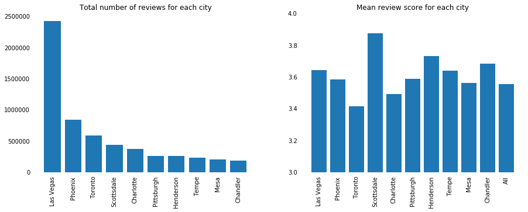

```python
#pivot table to get total reviews per city
cities_reviews = business.pivot_table(values='review_count', index='city', aggfunc=np.sum).sort_values('review_count', ascending=False)
cities_10 = cities_reviews[:10]

#pivot table to get mean review score for each city
mean_reviews = business.pivot_table(index='city', values='stars', aggfunc=np.mean, margins=True).sort_values('stars', ascending=False)

#subsetting for the top 10 cities in terms of total number of reviews
top_10_cities = list(cities_reviews.index[:10]).copy()
top_10_cities.append('All')
cities_10_mean = mean_reviews.loc[top_10_cities]

fig = plt.figure(figsize=(15,5))
ax1 = fig.add_subplot(1,2,1)
ax1.bar(cities_10.index, height=cities_10['review_count'])
ax1.set_xticklabels(labels= cities_10.index, rotation=90)
for key,spine in ax1.spines.items():
    spine.set_visible(False)
ax1.tick_params(left=False, bottom=False)
ax1.set_title('Total number of reviews for each city')

ax2 = fig.add_subplot(1,2,2)
ax2.bar(cities_10_mean.index, cities_10_mean['stars'])
ax2.set_ylim(3,4)
ax2.set_xticklabels(labels= cities_10_mean.index, rotation=90)
for key,spine in ax2.spines.items():
    spine.set_visible(False)
ax2.tick_params(left=False, bottom=False)
ax2.set_title('Mean review score for each city')

plt.show()
```

Another way of displaying the same information, with overlapping axes

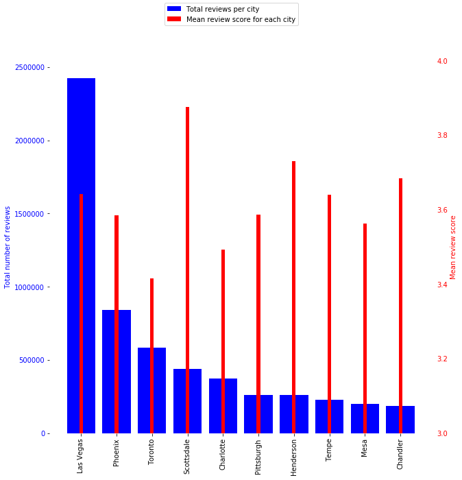

```python
#pivot table to get total reviews per city
cities_reviews = business.pivot_table(values='review_count', index='city', aggfunc=np.sum).sort_values('review_count', ascending=False)
cities_10 = cities_reviews[:10]

#pivot table to get mean review score for each city
mean_reviews = business.pivot_table(index='city', values='stars', aggfunc=np.mean, margins=True).sort_values('stars', ascending=False)

#subsetting for the top 10 cities in terms of total number of reviews
#we just omitted the 'All' row, contrary to the graph before, since we want to superpose both graphs
top_10_cities = list(cities_reviews.index[:10]).copy()
cities_10_mean = mean_reviews.loc[top_10_cities]

fig = plt.figure(figsize=(10,10))
ax1 = fig.add_subplot()
ax1.bar(cities_10.index, height=cities_10['review_count'], label='Total reviews per city', color='blue')
ax1.set_xticklabels(labels= cities_10.index, rotation=90)
for key,spine in ax1.spines.items():
    spine.set_visible(False)
ax1.tick_params(axis='y', labelcolor='blue', left=False, bottom=False, right=False, top=False)
ax1.set_ylabel('Total number of reviews',c='blue')

ax2 = ax1.twinx()
ax2.bar(cities_10_mean.index, cities_10_mean['stars'], width=0.1, label='Mean review score for each city', color='red')
ax2.set_ylim(3,4)
ax2.set_ylabel('Mean review score',c='red')
for key,spine in ax2.spines.items():
    spine.set_visible(False)
ax2.tick_params(axis='y', labelcolor='red', left=False, bottom=False, right=False, top=False)
fig.legend(loc='upper center')
plt.show()
```

So we can see that there is no trend between the number of reviews and the average rating of the businesses. In other words, a big concentration of businesses in a particular city is not a proxy for measuring the businesses' quality (as rated by customers).

# About businesses

### Most encountered business types

As we saw earlier, the 'categories' column is filled with str values representing categories separated by a comma and a blank space. Let's convert these values to a list and, say, we want to have a look at restaurants in particular. To do so, we will first select the rows containing the mention 'Restaurants', and consider that it is enough to select all the retaurants. By considering NaN as False, we state that rows with NaN as value in the 'categories' column aren't described and we won't consider them here.

```python
restaurants = business.copy()
restaurants = restaurants[restaurants['categories'].str.contains('Restaurants', na=False)]
restaurants.head(10)
```

|  | business_id | name | address | city | state | postal_code | latitude | longitude | stars | review_count | is_open | attributes | categories | hours |
| --- | --- | --- | --- | --- | --- | --- | --- | --- | --- | --- | --- | --- | --- | --- |
| 8 | pQeaRpvuhoEqudo3uymHIQ | The Empanadas House | 404 E Green St | Champaign | IL | 61820 | 40.110446 | -88.233073 | 4.5 | 5 | 1 | {'RestaurantsAttire': 'u'casual'', 'Restaurant... | Ethnic Food, Food Trucks, Specialty Food, Impo... | {'Monday': '11:30-14:30', 'Tuesday': '11:30-14... |
| 20 | CsLQLiRoafpJPJSkNX2h5Q | Middle East Deli | 4508 E Independence Blvd | Charlotte | NC | 28205 | 35.194894 | -80.767442 | 3.0 | 5 | 0 | {'RestaurantsGoodForGroups': 'True', 'OutdoorS... | Food, Restaurants, Grocery, Middle Eastern | None |
| 30 | 9sRGfSVEfLhN_km60YruTA | Apadana Restaurant | 13071 Yonge Street | Richmond Hill | ON | L4E 1A5 | 43.947011 | -79.454862 | 3.0 | 3 | 1 | {'Ambience': '{'touristy': False, 'hipster': F... | Persian/Iranian, Turkish, Middle Eastern, Rest... | {'Tuesday': '12:0-21:0', 'Wednesday': '12:0-21... |
| 33 | vjTVxnsQEZ34XjYNS-XUpA | Wetzel's Pretzels | 4550 East Cactus Rd, #KSFC-4 | Phoenix | AZ | 85032 | 33.602822 | -111.983533 | 4.0 | 10 | 1 | {'GoodForKids': 'True', 'RestaurantsTakeOut': ... | Food, Pretzels, Bakeries, Fast Food, Restaurants | {'Monday': '10:0-21:0', 'Tuesday': '10:0-21:0'... |
| 36 | fnZrZlqW1Z8iWgTVDfv_MA | Carl's Jr | 9595 W Tropicana Ave | Las Vegas | NV | 89147 | 36.099738 | -115.301568 | 2.5 | 15 | 0 | {'Alcohol': 'u'none'', 'WiFi': 'u'no'', 'GoodF... | Mexican, Restaurants, Fast Food | None |
| 38 | rVBPQdeayMYht4Uv_FOLHg | Gourmet Burger Company | 843 Kipling Avenue | Toronto | ON | M8Z 5G9 | 43.633291 | -79.531768 | 3.0 | 13 | 0 | {'RestaurantsPriceRange2': '2', 'RestaurantsAt... | Restaurants, Burgers, Food | None |
| 41 | 98hyK2QEUeI8v2y0AghfZA | Pho Lee's Vietnamese Restaurant | 1541 E 38th St, Ste 101 | Cleveland | OH | 44114 | 41.512155 | -81.663332 | 4.5 | 23 | 1 | {'BusinessParking': 'None', 'Ambience': '{'tou... | Restaurants, Vietnamese, Soup | {'Monday': '11:0-20:0', 'Wednesday': '11:0-20:... |
| 42 | fhNf_sg-XzZ3e7HEVGuOZg | Meat Chix And Wieners | 6530 S Decatur Blvd | Las Vegas | NV | 89118 | 36.071196 | -115.207463 | 3.0 | 10 | 0 | {'RestaurantsPriceRange2': '2', 'BusinessParki... | Burgers, Restaurants, American (Traditional), ... | {'Monday': '11:0-22:0', 'Tuesday': '11:0-22:0'... |
| 43 | LoRef3ChgZKbxUio-sHgQg | Amir | 5252 Rue Jean Talon O | Montréal | QC | H4P 2A7 | 45.494870 | -73.651904 | 3.0 | 18 | 1 | {'RestaurantsAttire': 'u'casual'', 'Restaurant... | Restaurants, Lebanese, Middle Eastern | None |
| 44 | Ga2Bt7xfqoggTypWD5VpoQ | Amando's Bros | 2602 W Southern Ave | Tempe | AZ | 85282 | 33.393199 | -111.976270 | 4.0 | 9 | 0 | {'Caters': 'False', 'RestaurantsGoodForGroups'... | Mexican, Restaurants | {'Monday': '7:0-20:0', 'Tuesday': '7:0-20:0', ... |

```python
restaurants = restaurants[restaurants['is_open'].notnull()]
```

Now let's see how we can study these restaurants.

```python
restaurants['categories'].value_counts()
```

```
Mexican, Restaurants                                                                                                                                          778
Restaurants, Mexican                                                                                                                                          757
Pizza, Restaurants                                                                                                                                            712
Restaurants, Pizza                                                                                                                                            707
Restaurants, Chinese                                                                                                                                          687
                                                                                                                                                             ...
Lounges, Food, Food Court, Restaurants, Nightlife, Middle Eastern, Bars, Hookah Bars                                                                            1
Nightlife, Lounges, Restaurants, Tapas Bars, Bars, American (New)                                                                                               1
Coffee & Tea, Taiwanese, Bubble Tea, Food, Restaurants                                                                                                          1
Beer, Wine & Spirits, American (Traditional), Food, Restaurants, Burgers                                                                                        1
Hawaiian, Restaurants, Asian Fusion, Caterers, Cajun/Creole, Comfort Food, Breakfast & Brunch, Food, Event Planning & Services, Barbeque, Sandwiches, Poke      1
Name: categories, Length: 28692, dtype: int64
```

There are a lot of information in the 'categories' column and we can see that some places are labeled as 'Mexican', others as 'Pizza' or 'Chinese'. There are obviously too many different categories to try and analyze them all, so we can either:

- group them, for example between different types of food (Mexican, Pizza, Burgers, ...)
- separate them between places that operate only as restaurants and mixed businesses that are both labeled as restaurants as well as Shop or Grocery..
- have a look at some particular cities and play with geographic data

Let's imagine we are a group of friends planning a trip across North America. We describe ourselves as big food enthusiasts and we want to plan where we will be eating for the first three cities we plan on visiting which are Las Vegas, Phoenix and Toronto. We want to discover what the restaurants scene look like in these three cities.  
Among our group, we agree on trying different types of food and set the following list:

- burgers and/or fast-foods and/or sandwiches
- steakhouses and/or american
- indian
- chinese
- thai
- french
- japanese and/or sushis
- mexican
- italian and/or pizzas
- mediterranean and/or middle eastern, lebanese, turkish and/or greek (anything with olive oil)
- cafes and/or bakeries (for the moments we'll want to relax, have a non-alcoholic drink or something sugary)

```python
#let's prepare the categories columns and work on another dataframe named trip
trip = restaurants.copy()
trip.reset_index(inplace=True)
trip.drop('index', axis=1, inplace=True)
#let's create a mapping dictionnary according to our list
categories_dict = {'Burgers':'Fast Food',
                  'Fast Food':'Fast Food',
                  'Sandwiches':'Fast Food',
                  'Steakhouses':'Steakhouses',
                  'American':'Steakhouses',
                  'Indian':'Indian',
                  'Chinese':'Chinese',
                  'Thai':'Thai',
                  'French':'French',
                  'Japanese':'Japanese',
                  'Sushi':'Japanese',
                  'Mexican':'Mexican',
                  'Italian':'Italian',
                  'Pizza':'Italian',
                  'Mediterranean':'Mediterranean',
                  'Lebanese':'Mediterranean',
                  'Middle Eastern':'Mediterranean',
                  'Turkish':'Mediterranean',
                  'Greek':'Mediterranean',
                  'Cafes':'Cafes',
                  'Bakeries':'Cafes'}
```

```python
#We use the .explode() method in order to split the categories column, creating duplicate rows for each business.
trip = trip.assign(categories = trip['categories'].str.split(', ')).explode('categories')
trip.head(10)
```

|  | business_id | name | address | city | state | postal_code | latitude | longitude | stars | review_count | is_open | attributes | categories | hours |
| --- | --- | --- | --- | --- | --- | --- | --- | --- | --- | --- | --- | --- | --- | --- |
| 0 | pQeaRpvuhoEqudo3uymHIQ | The Empanadas House | 404 E Green St | Champaign | IL | 61820 | 40.110446 | -88.233073 | 4.5 | 5 | 1 | {'RestaurantsAttire': 'u'casual'', 'Restaurant... | Ethnic Food | {'Monday': '11:30-14:30', 'Tuesday': '11:30-14... |
| 0 | pQeaRpvuhoEqudo3uymHIQ | The Empanadas House | 404 E Green St | Champaign | IL | 61820 | 40.110446 | -88.233073 | 4.5 | 5 | 1 | {'RestaurantsAttire': 'u'casual'', 'Restaurant... | Food Trucks | {'Monday': '11:30-14:30', 'Tuesday': '11:30-14... |
| 0 | pQeaRpvuhoEqudo3uymHIQ | The Empanadas House | 404 E Green St | Champaign | IL | 61820 | 40.110446 | -88.233073 | 4.5 | 5 | 1 | {'RestaurantsAttire': 'u'casual'', 'Restaurant... | Specialty Food | {'Monday': '11:30-14:30', 'Tuesday': '11:30-14... |
| 0 | pQeaRpvuhoEqudo3uymHIQ | The Empanadas House | 404 E Green St | Champaign | IL | 61820 | 40.110446 | -88.233073 | 4.5 | 5 | 1 | {'RestaurantsAttire': 'u'casual'', 'Restaurant... | Imported Food | {'Monday': '11:30-14:30', 'Tuesday': '11:30-14... |
| 0 | pQeaRpvuhoEqudo3uymHIQ | The Empanadas House | 404 E Green St | Champaign | IL | 61820 | 40.110446 | -88.233073 | 4.5 | 5 | 1 | {'RestaurantsAttire': 'u'casual'', 'Restaurant... | Argentine | {'Monday': '11:30-14:30', 'Tuesday': '11:30-14... |
| 0 | pQeaRpvuhoEqudo3uymHIQ | The Empanadas House | 404 E Green St | Champaign | IL | 61820 | 40.110446 | -88.233073 | 4.5 | 5 | 1 | {'RestaurantsAttire': 'u'casual'', 'Restaurant... | Food | {'Monday': '11:30-14:30', 'Tuesday': '11:30-14... |
| 0 | pQeaRpvuhoEqudo3uymHIQ | The Empanadas House | 404 E Green St | Champaign | IL | 61820 | 40.110446 | -88.233073 | 4.5 | 5 | 1 | {'RestaurantsAttire': 'u'casual'', 'Restaurant... | Restaurants | {'Monday': '11:30-14:30', 'Tuesday': '11:30-14... |
| 0 | pQeaRpvuhoEqudo3uymHIQ | The Empanadas House | 404 E Green St | Champaign | IL | 61820 | 40.110446 | -88.233073 | 4.5 | 5 | 1 | {'RestaurantsAttire': 'u'casual'', 'Restaurant... | Empanadas | {'Monday': '11:30-14:30', 'Tuesday': '11:30-14... |
| 1 | CsLQLiRoafpJPJSkNX2h5Q | Middle East Deli | 4508 E Independence Blvd | Charlotte | NC | 28205 | 35.194894 | -80.767442 | 3.0 | 5 | 0 | {'RestaurantsGoodForGroups': 'True', 'OutdoorS... | Food | None |
| 1 | CsLQLiRoafpJPJSkNX2h5Q | Middle East Deli | 4508 E Independence Blvd | Charlotte | NC | 28205 | 35.194894 | -80.767442 | 3.0 | 5 | 0 | {'RestaurantsGoodForGroups': 'True', 'OutdoorS... | Restaurants | None |

```python
#We categorize the categories column from trip dataframe thanks to our mapping dictionnary,
# according to our group's food list
trip['categories'] = trip['categories'].map(categories_dict)
#We drop the rows with categories that did not match our list
trip = trip[trip['categories'].notnull()]
#We eventually drop the duplicate rows created by the .explode() method. This action may be tricky to perform
# since one business could be associated with several categories in our list (if a business offers pizzas and burgers)
# we won't be too picky for this analysis and keep the first occurrence for each duplicate.
trip.drop_duplicates('business_id', inplace=True, ignore_index=True)
trip.head(20)
```

|  | business_id | name | address | city | state | postal_code | latitude | longitude | stars | review_count | is_open | attributes | categories | hours |
| --- | --- | --- | --- | --- | --- | --- | --- | --- | --- | --- | --- | --- | --- | --- |
| 0 | CsLQLiRoafpJPJSkNX2h5Q | Middle East Deli | 4508 E Independence Blvd | Charlotte | NC | 28205 | 35.194894 | -80.767442 | 3.0 | 5 | 0 | {'RestaurantsGoodForGroups': 'True', 'OutdoorS... | Mediterranean | None |
| 1 | 9sRGfSVEfLhN_km60YruTA | Apadana Restaurant | 13071 Yonge Street | Richmond Hill | ON | L4E 1A5 | 43.947011 | -79.454862 | 3.0 | 3 | 1 | {'Ambience': '{'touristy': False, 'hipster': F... | Mediterranean | {'Tuesday': '12:0-21:0', 'Wednesday': '12:0-21... |
| 2 | vjTVxnsQEZ34XjYNS-XUpA | Wetzel's Pretzels | 4550 East Cactus Rd, #KSFC-4 | Phoenix | AZ | 85032 | 33.602822 | -111.983533 | 4.0 | 10 | 1 | {'GoodForKids': 'True', 'RestaurantsTakeOut': ... | Cafes | {'Monday': '10:0-21:0', 'Tuesday': '10:0-21:0'... |
| 3 | fnZrZlqW1Z8iWgTVDfv_MA | Carl's Jr | 9595 W Tropicana Ave | Las Vegas | NV | 89147 | 36.099738 | -115.301568 | 2.5 | 15 | 0 | {'Alcohol': 'u'none'', 'WiFi': 'u'no'', 'GoodF... | Mexican | None |
| 4 | rVBPQdeayMYht4Uv_FOLHg | Gourmet Burger Company | 843 Kipling Avenue | Toronto | ON | M8Z 5G9 | 43.633291 | -79.531768 | 3.0 | 13 | 0 | {'RestaurantsPriceRange2': '2', 'RestaurantsAt... | Fast Food | None |
| 5 | fhNf_sg-XzZ3e7HEVGuOZg | Meat Chix And Wieners | 6530 S Decatur Blvd | Las Vegas | NV | 89118 | 36.071196 | -115.207463 | 3.0 | 10 | 0 | {'RestaurantsPriceRange2': '2', 'BusinessParki... | Fast Food | {'Monday': '11:0-22:0', 'Tuesday': '11:0-22:0'... |
| 6 | LoRef3ChgZKbxUio-sHgQg | Amir | 5252 Rue Jean Talon O | Montréal | QC | H4P 2A7 | 45.494870 | -73.651904 | 3.0 | 18 | 1 | {'RestaurantsAttire': 'u'casual'', 'Restaurant... | Mediterranean | None |
| 7 | Ga2Bt7xfqoggTypWD5VpoQ | Amando's Bros | 2602 W Southern Ave | Tempe | AZ | 85282 | 33.393199 | -111.976270 | 4.0 | 9 | 0 | {'Caters': 'False', 'RestaurantsGoodForGroups'... | Mexican | {'Monday': '7:0-20:0', 'Tuesday': '7:0-20:0', ... |
| 8 | xFc50drSPxXkcLvX5ygqrg | Boomer's Sweet Home Chicago | 5932 W Bell Rd, Ste D-109 | Glendale | AZ | 85308 | 33.640391 | -112.187028 | 3.5 | 12 | 0 | {'BusinessAcceptsCreditCards': 'True', 'Busine... | Fast Food | None |
| 9 | tLpkSwdtqqoXwU0JAGnApw | Wendy's | 4602 Northfield Road | Cleveland | OH | 44128 | 41.434614 | -81.527026 | 3.5 | 7 | 1 | {'RestaurantsDelivery': 'False', 'BusinessAcce... | Fast Food | {'Monday': '10:0-3:0', 'Tuesday': '10:0-3:0', ... |
| 10 | Sd75ucXKoZUM2BEfBHFUOg | China Gourmet | 3460 E Southern Ave, Ste 109 | Mesa | AZ | 85204 | 33.394863 | -111.756036 | 3.0 | 13 | 0 | {'RestaurantsPriceRange2': '1', 'RestaurantsAt... | Chinese | None |
| 11 | lK-wuiq8b1TuU7bfbQZgsg | Hingetown |  | Cleveland | OH | 44113 | 41.489343 | -81.711029 | 3.0 | 4 | 1 | {'Alcohol': 'u'none'', 'GoodForKids': 'True', ... | Cafes | {'Monday': '0:0-0:0', 'Tuesday': '0:0-0:0', 'W... |
| 12 | LAoSegVNU4wx4GTA8reB6A | Tzikii Food Truck | 7510 S Priest Dr | Tempe | AZ | 85283 | 33.350104 | -111.963660 | 3.0 | 4 | 1 | {'RestaurantsTakeOut': 'False', 'WheelchairAcc... | Mediterranean | None |
| 13 | -qjn24n8HYF6It9GQrQntw | Five Guys Burgers and Fries | 2130 E Arbors Dr | Charlotte | NC | 28262 | 35.338070 | -80.757397 | 4.0 | 15 | 0 | {'RestaurantsReservations': 'False', 'Restaura... | Fast Food | {'Monday': '11:0-22:0', 'Tuesday': '11:0-22:0'... |
| 14 | RrapAhd8ZxCj-iue7fu9FA | Ganga Restaurant | 515 4th Avenue SW | Calgary | AB | T2P 0J8 | 51.049407 | -114.072656 | 1.5 | 3 | 1 | {'RestaurantsReservations': 'True', 'WiFi': 'u... | Indian | {'Monday': '17:0-22:0', 'Tuesday': '17:0-22:0'... |
| 15 | OWkS1FXNJbozn-qPg3LWxg | Mama Napoli Pizza |  | Las Vegas | NV | 89109 | 36.128561 | -115.171130 | 4.5 | 11 | 1 | {'RestaurantsDelivery': 'False', 'BusinessAcce... | Italian | {'Friday': '18:0-0:0'} |
| 16 | j9bWpCRwpDVfwVT_V85qeA | Papaya Thai | 2706 E University Dr | Mesa | AZ | 85213 | 33.423705 | -111.772890 | 2.5 | 130 | 1 | {'Caters': 'False', 'OutdoorSeating': 'False',... | Thai | {'Monday': '11:0-21:0', 'Tuesday': '11:0-21:0'... |
| 17 | 6GHwgKNlvfIMUpFaxgBjUA | L'Artisan Piadineria | 3421 Rue Saint-Denis | Montréal | QC | H2L 3L2 | 45.517369 | -73.567940 | 4.0 | 9 | 0 | {'RestaurantsTakeOut': 'True', 'Ambience': '{'... | Fast Food | {'Monday': '9:0-17:0', 'Tuesday': '9:0-17:0', ... |
| 18 | Ir_QIzs-4o9ElOtiGuxJrw | Torteria Lupita | 4601 Rue Notre-Dame O | Montréal | QC | H4C 1S5 | 45.473632 | -73.588135 | 4.0 | 19 | 0 | {'RestaurantsPriceRange2': '2', 'BusinessParki... | Mexican | {'Tuesday': '12:0-20:0', 'Wednesday': '12:0-20... |
| 19 | JcsZvx-4yovFgCXOfd6KMg | Sam's Deli Mart | 3300 N Central Ave Lbby | Phoenix | AZ | 85012 | 33.648302 | -112.119379 | 3.0 | 4 | 0 | {'RestaurantsTakeOut': 'True', 'RestaurantsGoo... | Fast Food | None |

```python
#Let's remove the rows corresponding to closed businesses
trip = trip[trip['is_open']==1]
trip = trip.drop('is_open', axis=1)
trip.reset_index(inplace=True)
```

```python
trip.sort_values(['stars', 'review_count'], ascending=False).head()
```

|  | index | business_id | name | address | city | state | postal_code | latitude | longitude | stars | review_count | attributes | categories | hours |
| --- | --- | --- | --- | --- | --- | --- | --- | --- | --- | --- | --- | --- | --- | --- |
| 1539 | 2232 | IhNASEZ3XnBHmuuVnWdIwA | Brew Tea Bar | 7380 S Rainbow Blvd, Ste 101 | Las Vegas | NV | 89139 | 36.054227 | -115.242392 | 5.0 | 1827 | {'HasTV': 'False', 'OutdoorSeating': 'True', '... | Cafes | {'Monday': '0:0-0:0', 'Tuesday': '11:0-22:0', ... |
| 19421 | 28202 | 9MVKjEMN5T59uzG1xoD2BQ | Cocina Madrigal | 4044 S 16th St | Phoenix | AZ | 85040 | 33.408767 | -112.047381 | 5.0 | 1107 | {'GoodForKids': 'True', 'WiFi': 'u'free'', 'Re... | Mexican | {'Monday': '0:0-0:0', 'Tuesday': '11:0-21:0', ... |
| 20221 | 29358 | 16d3BlncEyCTzb0GxXrBXQ | Green Corner Restaurant | 1038 W Southern Ave, Ste 1 | Mesa | AZ | 85210 | 33.394446 | -111.854111 | 5.0 | 858 | {'RestaurantsGoodForGroups': 'True', 'Restaura... | Mediterranean | {'Monday': '10:30-22:0', 'Tuesday': '10:30-22:... |
| 2049 | 2972 | SSCH4Z2gw-hh2KZy7aH4qw | Worth Takeaway | 218 W Main St | Mesa | AZ | 85201 | 33.415461 | -111.837432 | 5.0 | 842 | {'DogsAllowed': 'True', 'BusinessParking': '{'... | Fast Food | {'Monday': '0:0-0:0', 'Tuesday': '8:0-16:0', '... |
| 5628 | 8158 | 8fFTJBh0RB2EKG53ibiBKw | Zenaida's Cafe | 3430 E Tropicana Ave, Ste 32 | Las Vegas | NV | 89121 | 36.101741 | -115.100359 | 5.0 | 717 | {'DogsAllowed': 'False', 'GoodForMeal': '{'des... | Cafes | {'Wednesday': '8:0-14:0', 'Thursday': '8:0-14:... |

```python
trip['city'].value_counts()
```

```
Toronto          3853
Las Vegas        3470
Phoenix          2158
Montréal         2008
Calgary          1607
Charlotte        1430
Pittsburgh       1214
Mississauga       922
Cleveland         715
Scottsdale        684
Mesa              663
Madison           519
Tempe             511
Markham           479
Henderson         453
Chandler          448
Glendale          431
Brampton          392
Gilbert           331
Scarborough       317
Vaughan           298
Richmond Hill     277
North York        255
Concord           219
Peoria            214
Champaign         204
Etobicoke         203
Surprise          142
Gastonia          132
Avondale          128
Mentor            120
Goodyear          120
Akron             109
Matthews          107
Huntersville      100
Fort Mill          99
Lakewood           86
Name: city, dtype: int64
```

Say we focus on the first city we'll visit: Toronto. Since we are staying three nigths, we agreed on eating Mediterranean, Chinese and French food.

```python
toronto = trip[trip['city']=='Toronto']
toronto['categories'].value_counts()
```

```
Fast Food        907
Italian          580
Cafes            545
Chinese          401
Mediterranean    380
Japanese         349
Indian           223
Thai             173
Mexican          160
French            81
Steakhouses       54
Name: categories, dtype: int64
```

Let's try to see where are the 10 top places for each food type in Toronto!

```python
#we order the restaurants considering the number of reviews first in order to select already 'famous' places,
# then order by 'stars'
#mediterranean restaurants
toronto_med_10 = toronto[toronto['categories']=='Mediterranean'].sort_values(['review_count','stars'], ascending=False).head(10)
med_latlon = toronto_med_10[['latitude','longitude']].values.tolist()
# print(med_latlon)

#Chinese restaurants
toronto_chin_10 = toronto[toronto['categories']=='Chinese'].sort_values(['review_count','stars'], ascending=False).head(10)
chin_latlon = toronto_chin_10[['latitude','longitude']].values.tolist()

#French restaurants
toronto_fr_10 = toronto[toronto['categories']=='French'].sort_values(['review_count','stars'], ascending=False).head(10)
fr_latlon = toronto_fr_10[['latitude','longitude']].values.tolist()

map = folium.Map(location=[43.651070, -79.347015], tiles='Stamen Toner', zoom_start=12)
for point in range(0, len(med_latlon)):
    folium.Marker(med_latlon[point], popup=toronto_med_10.iloc[point, 2], icon=folium.Icon(color='darkblue')).add_to(map)
    folium.Marker(chin_latlon[point], popup=toronto_chin_10.iloc[point, 2], icon=folium.Icon(color='red')).add_to(map)
    folium.Marker(fr_latlon[point], popup=toronto_fr_10.iloc[point, 2], icon=folium.Icon(color='green')).add_to(map)
map
```

[interactive chart not shown]

We can see the high concentration of Chinese restaurants on Spadina Avenue in Toronto. Mediterranean and French restaurants seem to be more dispersed around the city.

Let's have a look at the review distribution for each food category

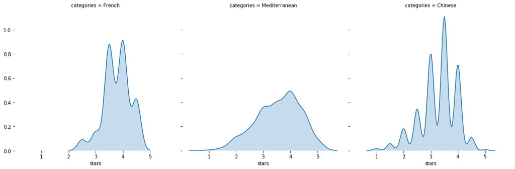

```python
toronto_selection = toronto[(toronto['categories']=='Mediterranean')
                            | (toronto['categories']=='French')
                            | (toronto['categories']=='Chinese')]
g = sns.FacetGrid(toronto_selection,col='categories',height=5)
sns.despine(bottom=True, left=True)
g.map(sns.kdeplot, 'stars', shade=True)
```

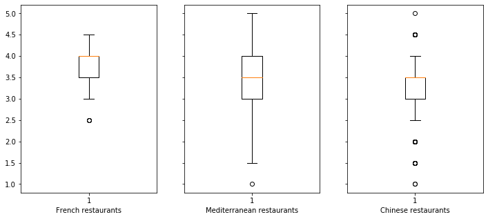

```python
fig, (ax1,ax2,ax3) = plt.subplots(1,3, figsize=(12,5), sharey=True)
ax1.boxplot(toronto[toronto['categories']=='French']['stars'])
ax1.set_xlabel('French restaurants')
ax2.boxplot(toronto[toronto['categories']=='Mediterranean']['stars'])
ax2.set_xlabel('Mediterranean restaurants')
ax3.boxplot(toronto[toronto['categories']=='Chinese']['stars'])
ax3.set_xlabel('Chinese restaurants')
plt.show()
```

We can see that among these three categories, it seems that French restaurants benefit from better reviews (a majority of scores between 3.5 and 4.5), whereas Mediterranean and Chinese restaurants reviews are a bit more dispersed.

To read the review json file, we first tried to do the same as checkin and business but the command took too much time since the file is 6M lines long..  
We found a solution from George Hou who's writing for [TowardsDataScience](https://towardsdatascience.com/converting-yelp-dataset-to-csv-using-pandas-2a4c8f03bd88).  
We read it by chunks of 1M lines and use the documentation provided by [Yelp](https://www.yelp.fr/dataset/documentation/main) to set the data type for each column.

```python
# size=1000000
# review_json_path = 'yelp_academic_dataset_review.json'
# review = pd.read_json(review_json_path, lines=True,
#                       dtype={'review_id':str, 'user_id':str, 'business_id':str, 'stars':int, 'date':str, 'text':str, 'useful':int, 'funny':int, 'cool':int},
#                       chunksize=size)
```

```python
# tip_json_path = 'yelp_academic_dataset_tip.json'
# tip = pd.read_json(tip_json_path, lines=True)
```

```python
# tip.info()
```